# Wind Summer Steelhead Mark-Resight and “jumper” ratio estimates from August to September

Thomas Buehrens (tbuehrens@dfw.wa.gov) & Charlie Cochran (patrick.cochran@dfw.wa.gov)

Last Updated 10/18/2022.

## Background

Estimates of Wind River wild summer steelhead runsize above Shipherd Falls are made by tagging the subset of summer steelhead that use the fish ladder (while others jump the falls) as they pass upstream. Riverscape snorkel surveys are conducted in August and September to enumerate tagged and un-tagged steelhead upstream of the falls, and enable abundance estimation via a Lincoln-Petersen estimate.These estimates are incomplete because steelhead continue to pass the falls after the September survey. Sometime in the fall, usually in October, a combination of high flows and decreasing temperatures preclude summer steelhead from jumping the falls from that point on until the migration has ended for that spawn year in the following spring. However, from the September snorkel until the end of the jumping period, the falls trap count is not a census count and therefore must be expanded to account for steelhead that jumped the falls and were not caught in the trap.To accomplish this a jumper ratio is calculated as:

Equation. 1):

(September Snorkel Abundance - August Snorkel Abundance) / (September Snorkel Trap Count - August Snorkel Trap Count)

This “jumper ratio” is then multiplied by trap counts between the September snorkel and the end of the jumping period to account for untrapped fish.

The final abundance estimate is the sum of: 1) the September snorkel abundance 2) the jumper ratio expanded trap count between September and the end of the jumping period 3) a census count of steelhead trapped between the end of jumping and the end of the run.

The actual equations used to calculate the jumper ratio differ from equation 1 in order to account for and propagate uncertainty in abundance estimates, and noise in the trap counts due to discreteness. Full details are shown in the data and model appendices below.

```r
#function to install or load packages
logit<-function(x){log(x/(1-x))}

install_or_load_pack <- function(pack){
  create.pkg <- pack[!(pack %in% installed.packages()[, "Package"])]
  if (length(create.pkg))
    install.packages(create.pkg, dependencies = TRUE,repos = "http://cran.us.r-project.org")
  sapply(pack, require, character.only = TRUE)
}

packages<-c("tidyverse","rstan","ggplot2","kableExtra","lubridate")
install_or_load_pack(packages)
```

```r
dat<-read_csv("data/jumper_data.csv")%>%
  dplyr::rename(
    tr = trap_count_septminusaug,
    N_aug_obs = august_estimate,
    N_sept_obs = september_estimate,
  )%>%
  mutate(
    N_aug_sd_obs = sqrt(log(august_cv^2+1)) ,
    N_sept_sd_obs = sqrt(log(september_cv^2+1))
  )


years = min(dat$year) : max(dat$year)
years = years - min(years) + 1
yrs=length(years)
a_years = years[!is.na(dat$N_aug_sd_obs)]
a_yrs = length(a_years)
s_years = years[!is.na(dat$N_sept_sd_obs)]
s_yrs = length(s_years)
obs_years = s_years[s_years%in%a_years]
obs_yrs = length(obs_years)

stan_dat<-dat%>%
  as.list()

stan_dat$years = years
stan_dat$yrs = yrs
stan_dat$a_years = a_years
stan_dat$a_yrs = a_yrs
stan_dat$s_years = s_years
stan_dat$s_yrs = s_yrs
stan_dat$obs_years = obs_years
stan_dat$obs_yrs = obs_yrs

stan_dat<-lapply(stan_dat,function(x) x[!is.na(x)])
```

```r
# run the MCMC
if(!file.exists("results/jumper_results.rds")){
  start.time<-Sys.time()
  if(!file.exists("model/model.rds")){
    model<-stan_model("model/jumper.stan")
    saveRDS(model,"model/model.rds")
  }else{
    model<-readRDS("model/model.rds")
  }
m1 <-sampling(
    object = model,
    data=stan_dat,
    #inits=0,
    cores = 4,
    chains=4, #Number of chains
    iter=4000, #number of iterations
    warmup=2000, #number of burn in
    thin=1 #thinning rate
  )
  end.time<-Sys.time();print(end.time-start.time)

  #save jags run, results
  saveRDS(m1,"results/jumper_results.rds")
  write.csv(summary(m1)$summary,"results/summary.csv")
}else{
  m1<-readRDS("results/jumper_results.rds")
}
```

## Results

Below are plots and tables of the “jumper ratio” and model smoothed vs. raw “observed” mark-recapture abundance estimates in August and September.

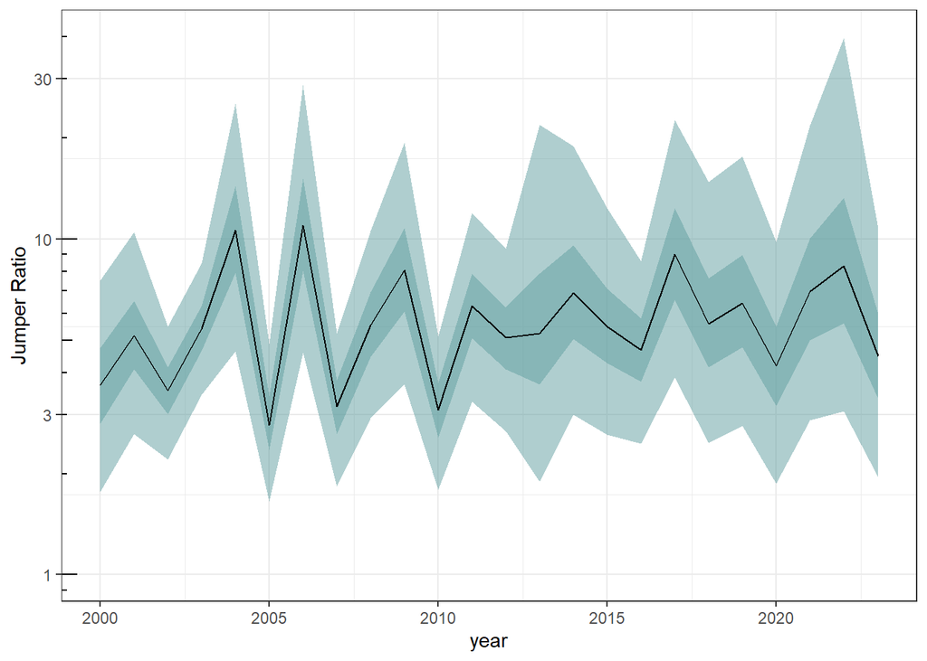

```r
results<-rstan::extract(m1)

jr<-t(apply(1/results$p_tr,2,function(x) quantile(x,c(0.025,0.25,0.5,0.75,0.975))))%>%
  as_tibble()%>%
  bind_cols(tibble(year=min(dat$year):max(dat$year)))

ggplot(jr, aes(x=year,y=`50%`))+
  geom_ribbon(aes(ymin=`2.5%`,ymax=`97.5%`),fill="cadetblue",color="NA",alpha=0.5)+
  geom_ribbon(aes(ymin=`25%`,ymax=`75%`),fill="cadetblue",color="NA",alpha=0.5)+
  geom_line()+
  ylab("Jumper Ratio")+
  theme_bw()+
  scale_y_log10(limits=c(1,40))+
  annotation_logticks(side="l")
```

```r
jr%>%
  dplyr::rename(spawn_year = year)%>%
  kbl(caption = "Table 1.The ratio of wild steelhead jumping Shipherd Falls to the number caught in the trap between the August and September snorkels (aka the `Jumper Ratio')",digits =3)%>%
  kable_classic(full_width = F, html_font = "Cambria")
```

Table 1.The ratio of wild steelhead jumping Shipherd Falls to the number caught in the trap between the August and September snorkels (aka the `Jumper Ratio’)

| 2.5% | 25% | 50% | 75% | 97.5% | spawn_year |
| --- | --- | --- | --- | --- | --- |
| 1.768 | 2.819 | 3.667 | 4.727 | 7.510 | 2000 |
| 2.625 | 4.097 | 5.160 | 6.526 | 10.466 | 2001 |
| 2.204 | 3.007 | 3.538 | 4.147 | 5.484 | 2002 |
| 3.437 | 4.651 | 5.418 | 6.305 | 8.468 | 2003 |
| 4.632 | 7.944 | 10.621 | 14.349 | 25.308 | 2004 |
| 1.650 | 2.351 | 2.797 | 3.397 | 4.863 | 2005 |
| 4.586 | 8.046 | 10.997 | 15.113 | 28.809 | 2006 |
| 1.837 | 2.626 | 3.173 | 3.800 | 5.221 | 2007 |
| 2.929 | 4.465 | 5.539 | 6.939 | 10.552 | 2008 |
| 3.680 | 6.091 | 8.066 | 10.784 | 19.372 | 2009 |
| 1.792 | 2.568 | 3.094 | 3.719 | 5.121 | 2010 |
| 3.275 | 5.060 | 6.324 | 7.879 | 11.969 | 2011 |
| 2.678 | 4.091 | 5.078 | 6.264 | 9.370 | 2012 |
| 1.892 | 3.681 | 5.236 | 7.894 | 21.885 | 2013 |
| 2.997 | 5.033 | 6.911 | 9.587 | 18.925 | 2014 |
| 2.613 | 4.269 | 5.483 | 7.097 | 12.365 | 2015 |
| 2.462 | 3.760 | 4.665 | 5.797 | 8.598 | 2016 |
| 3.866 | 6.593 | 9.017 | 12.353 | 22.595 | 2017 |
| 2.467 | 4.153 | 5.596 | 7.640 | 14.800 | 2018 |
| 2.776 | 4.757 | 6.435 | 8.967 | 17.583 | 2019 |
| 1.869 | 3.187 | 4.185 | 5.480 | 9.803 | 2020 |
| 2.879 | 4.990 | 6.969 | 10.044 | 21.811 | 2021 |
| 3.072 | 5.617 | 8.296 | 13.238 | 39.572 | 2022 |
| 1.951 | 3.343 | 4.469 | 5.968 | 10.699 | 2023 |

```r
hier_jr<-quantile(1/results$hier_p_tr,c(0.025,0.25,0.5,0.75,0.975))%>%
  as.data.frame()%>%
  rownames_to_column()%>%
  dplyr::rename(quantile ="rowname",hier_jr=".")%>%
  as_tibble()

hier_jr%>%
  kbl(caption = "Table 2.The hierarchical jumper rate" ,digits =3)%>%
  kable_classic(full_width = F, html_font = "Cambria")
```

Table 2.The hierarchical jumper rate

| quantile | hier_jr |
| --- | --- |
| 2.5% | 1.949 |
| 25% | 3.725 |
| 50% | 5.291 |
| 75% | 7.866 |
| 97.5% | 22.374 |

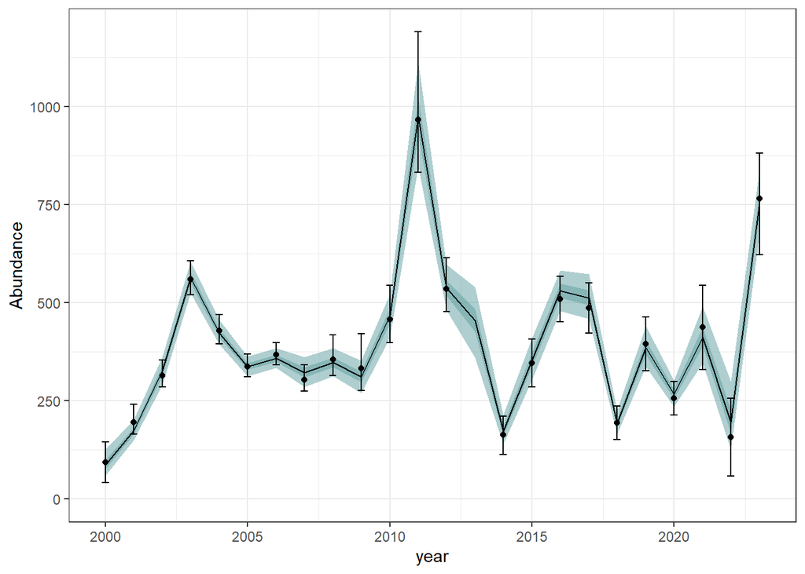

```r
N_aug<-t(apply(results$N_aug,2,function(x) quantile(x,c(0.025,0.25,0.5,0.75,0.975))))%>%
  as_tibble()%>%
  bind_cols(tibble(year=min(dat$year):max(dat$year)))%>%
  left_join(dat%>%dplyr::select(year,N_aug_obs,august_l95,august_u95))

ggplot(N_aug, aes(x=year,y=`50%`))+
  geom_ribbon(aes(ymin=`2.5%`,ymax=`97.5%`),fill="cadetblue",color="NA",alpha=0.5)+
  geom_ribbon(aes(ymin=`25%`,ymax=`75%`),fill="cadetblue",color="NA",alpha=0.5)+
  geom_line()+
  geom_errorbar(aes(ymax = august_u95,ymin=august_l95),width = 0.25)+
  geom_point(aes(x=year,y=N_aug_obs))+
  ylab("Abundance")+
  theme_bw()+
  ylim(0,NA)
```

```r
N_aug%>%
  dplyr::rename(spawn_year = year)%>%
  kbl(caption = "Table 3.The smoothed  & observed August mark-resight abundance of wild Wind River summer steelhead",digits =3)%>%
  kable_classic(full_width = F, html_font = "Cambria")
```

Table 3.The smoothed & observed August mark-resight abundance of wild Wind River summer steelhead

| 2.5% | 25% | 50% | 75% | 97.5% | spawn_year | N_aug_obs | august_l95 | august_u95 |
| --- | --- | --- | --- | --- | --- | --- | --- | --- |
| 60.030 | 77.469 | 87.937 | 99.491 | 126.651 | 2000 | 94 | 42 | 146 |
| 149.498 | 165.180 | 173.684 | 182.557 | 200.886 | 2001 | 196 | 165 | 242 |
| 291.000 | 314.559 | 327.367 | 339.568 | 363.679 | 2002 | 315 | 285 | 354 |
| 524.982 | 550.569 | 564.490 | 578.547 | 605.198 | 2003 | 559 | 520 | 607 |
| 394.289 | 412.472 | 422.928 | 433.839 | 456.749 | 2004 | 428 | 395 | 470 |
| 313.577 | 329.539 | 337.953 | 346.726 | 363.203 | 2005 | 337 | 312 | 369 |
| 334.012 | 349.902 | 358.620 | 367.329 | 384.292 | 2006 | 367 | 342 | 398 |
| 285.667 | 309.428 | 322.531 | 335.837 | 360.877 | 2007 | 303 | 274 | 342 |
| 313.072 | 335.672 | 348.301 | 360.525 | 384.664 | 2008 | 356 | 314 | 418 |
| 270.705 | 297.082 | 310.583 | 325.255 | 351.991 | 2009 | 332 | 276 | 421 |
| 411.517 | 448.738 | 467.815 | 487.091 | 523.385 | 2010 | 458 | 398 | 544 |
| 847.048 | 929.970 | 974.927 | 1022.569 | 1115.594 | 2011 | 967 | 833 | 1190 |
| 482.587 | 519.241 | 538.443 | 558.766 | 597.688 | 2012 | 536 | 477 | 615 |
| 359.935 | 425.076 | 455.238 | 483.574 | 539.703 | 2013 | NA | NA | NA |
| 139.111 | 161.021 | 172.924 | 186.169 | 214.000 | 2014 | 163 | 114 | 211 |
| 304.092 | 336.887 | 354.579 | 373.190 | 409.718 | 2015 | 346 | 285 | 407 |
| 479.412 | 512.759 | 531.425 | 549.177 | 582.846 | 2016 | 509 | 451 | 567 |
| 458.457 | 493.865 | 512.972 | 532.897 | 573.050 | 2017 | 487 | 423 | 551 |
| 164.870 | 182.681 | 192.624 | 203.508 | 225.336 | 2018 | 194 | 151 | 236 |
| 337.841 | 368.085 | 385.707 | 403.748 | 440.114 | 2019 | 395 | 326 | 464 |
| 234.838 | 255.556 | 267.285 | 279.080 | 302.785 | 2020 | 257 | 214 | 299 |
| 345.993 | 388.562 | 412.356 | 438.320 | 491.678 | 2021 | 437 | 330 | 545 |
| 125.126 | 168.381 | 195.548 | 226.808 | 299.380 | 2022 | 157 | 59 | 256 |
| 675.051 | 727.680 | 755.820 | 785.016 | 841.976 | 2023 | 766 | 622 | 881 |

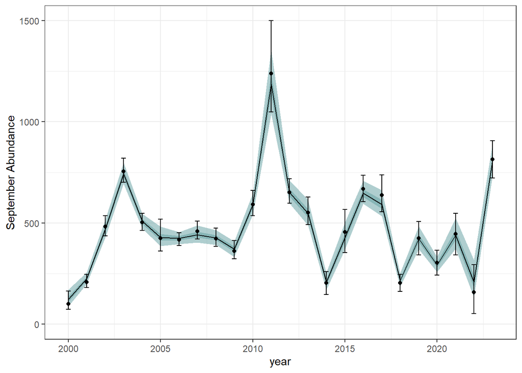

```r
N_sept<-t(apply(results$N_sept,2,function(x) quantile(x,c(0.025,0.25,0.5,0.75,0.975))))%>%
  as_tibble()%>%
  bind_cols(tibble(year=min(dat$year):max(dat$year)))%>%
  left_join(dat%>%dplyr::select(year,N_sept_obs,september_l95,september_u95))

ggplot(N_sept, aes(x=year,y=`50%`))+
  geom_ribbon(aes(ymin=`2.5%`,ymax=`97.5%`),fill="cadetblue",color="NA",alpha=0.5)+
  geom_ribbon(aes(ymin=`25%`,ymax=`75%`),fill="cadetblue",color="NA",alpha=0.5)+
  geom_line()+
  geom_errorbar(aes(ymax = september_u95,ymin=september_l95), width = 0.25)+
  geom_point(aes(x=year,y=N_sept_obs))+
  ylab("September Abundance")+
  theme_bw()+
  ylim(0,NA)
```

```r
N_sept%>%
  dplyr::rename(spawn_year = year)%>%
  kbl(caption = "Table 4.The smoothed & observed September mark-resight abundance of wild Wind River summer steelhead",digits =3)%>%
  kable_classic(full_width = F, html_font = "Cambria")
```

Table 4.The smoothed & observed September mark-resight abundance of wild Wind River summer steelhead

| 2.5% | 25% | 50% | 75% | 97.5% | spawn_year | N_sept_obs | september_l95 | september_u95 |
| --- | --- | --- | --- | --- | --- | --- | --- | --- |
| 88.930 | 110.029 | 122.845 | 137.434 | 171.371 | 2000 | 101 | 73 | 163 |
| 197.636 | 215.355 | 225.036 | 235.122 | 256.669 | 2001 | 208 | 181 | 246 |
| 429.360 | 456.115 | 470.621 | 485.921 | 517.428 | 2002 | 482 | 437 | 537 |
| 693.962 | 726.225 | 743.874 | 761.959 | 799.291 | 2003 | 755 | 701 | 821 |
| 473.018 | 496.211 | 508.349 | 521.522 | 546.268 | 2004 | 504 | 464 | 548 |
| 387.337 | 413.004 | 428.523 | 445.185 | 482.318 | 2005 | 424 | 361 | 518 |
| 396.657 | 415.424 | 425.660 | 435.853 | 456.243 | 2006 | 417 | 389 | 452 |
| 404.398 | 428.555 | 442.880 | 457.698 | 487.987 | 2007 | 460 | 421 | 509 |
| 391.889 | 414.958 | 427.469 | 439.851 | 464.495 | 2008 | 423 | 384 | 475 |
| 333.216 | 357.434 | 370.384 | 383.630 | 410.162 | 2009 | 362 | 324 | 413 |
| 542.665 | 574.090 | 592.063 | 609.844 | 646.958 | 2010 | 592 | 537 | 660 |
| 1038.727 | 1134.006 | 1187.127 | 1242.426 | 1358.794 | 2011 | 1238 | 1048 | 1499 |
| 598.427 | 632.288 | 651.108 | 670.947 | 711.621 | 2012 | 651 | 597 | 719 |
| 487.804 | 526.344 | 546.904 | 568.309 | 614.576 | 2013 | 551 | 492 | 628 |
| 170.000 | 193.700 | 207.450 | 221.974 | 254.118 | 2014 | 204 | 147 | 260 |
| 368.772 | 406.562 | 428.258 | 452.271 | 503.254 | 2015 | 455 | 354 | 566 |
| 596.507 | 628.674 | 647.374 | 667.340 | 707.884 | 2016 | 669 | 606 | 736 |
| 533.463 | 571.289 | 592.486 | 614.375 | 662.850 | 2017 | 637 | 556 | 737 |
| 185.525 | 204.763 | 216.244 | 227.765 | 251.727 | 2018 | 204 | 161 | 247 |
| 370.431 | 404.773 | 423.504 | 443.457 | 483.390 | 2019 | 425 | 342 | 508 |
| 258.415 | 280.541 | 293.080 | 306.440 | 333.523 | 2020 | 303 | 242 | 365 |
| 372.767 | 416.080 | 440.750 | 467.913 | 524.831 | 2021 | 445 | 343 | 547 |
| 133.567 | 179.278 | 207.650 | 240.392 | 316.871 | 2022 | 159 | 53 | 295 |
| 733.339 | 784.185 | 810.702 | 838.242 | 893.284 | 2023 | 814 | 723 | 906 |

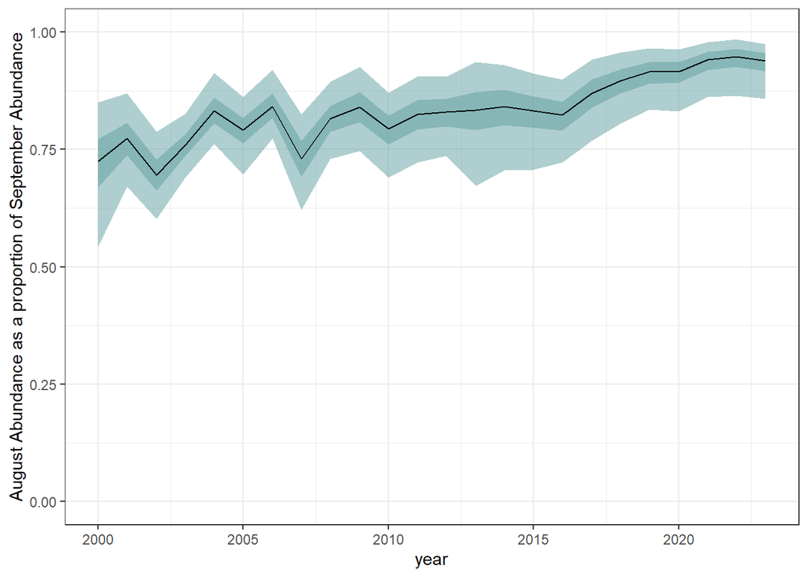

```r
wdat<-readr::read_delim(paste0("https://waterdata.usgs.gov/nwis/monthly?site_no=14105700&agency_cd=USGS&por_14105700_113462=546282,00010,113462,1996-06,",year(Sys.Date()),"-",month(Sys.Date()),"&referred_module=sw&format=rdb"),comment = '#')%>%
  filter(agency_cd=="USGS" & month_nu == 8)%>%
  mutate(year=year_nu+1,mean_water_temp=as.numeric(mean_va))%>%
  dplyr::select(year,mean_water_temp)


p_aug<-t(apply(results$p_aug,2,function(x) quantile(x,c(0.025,0.25,0.5,0.75,0.975))))%>%
  as_tibble()%>%
  bind_cols(tibble(year=min(dat$year):max(dat$year)))%>%
  left_join(wdat)

ggplot(p_aug, aes(x=year,y=`50%`))+
  geom_ribbon(aes(ymin=`2.5%`,ymax=`97.5%`),fill="cadetblue",color="NA",alpha=0.5)+
  geom_ribbon(aes(ymin=`25%`,ymax=`75%`),fill="cadetblue",color="NA",alpha=0.5)+
  geom_line()+
  ylab("August Abundance as a proportion of September Abundance")+
  theme_bw()+
  ylim(0,1)
```

```r
p_aug%>%
  dplyr::rename(spawn_year = year)%>%
  kbl(caption = "Table 5.August abundance as a proportion of September abundance of wild Wind River summer steelhead",digits =3)%>%
  kable_classic(full_width = F, html_font = "Cambria")
```

Table 5.August abundance as a proportion of September abundance of wild Wind River summer steelhead

| 2.5% | 25% | 50% | 75% | 97.5% | spawn_year | mean_water_temp |
| --- | --- | --- | --- | --- | --- | --- |
| 0.543 | 0.670 | 0.725 | 0.772 | 0.850 | 2000 | 20.65 |
| 0.671 | 0.738 | 0.774 | 0.807 | 0.870 | 2001 | 21.08 |
| 0.602 | 0.663 | 0.696 | 0.729 | 0.788 | 2002 | 21.67 |
| 0.690 | 0.736 | 0.760 | 0.783 | 0.826 | 2003 | 20.74 |
| 0.762 | 0.806 | 0.832 | 0.860 | 0.913 | 2004 | 22.11 |
| 0.697 | 0.763 | 0.791 | 0.818 | 0.862 | 2005 | 22.43 |
| 0.774 | 0.817 | 0.842 | 0.869 | 0.920 | 2006 | 21.77 |
| 0.621 | 0.692 | 0.731 | 0.769 | 0.825 | 2007 | 21.41 |
| 0.731 | 0.788 | 0.816 | 0.843 | 0.894 | 2008 | 21.17 |
| 0.746 | 0.808 | 0.840 | 0.872 | 0.926 | 2009 | 20.97 |
| 0.690 | 0.761 | 0.794 | 0.823 | 0.872 | 2010 | 21.79 |
| 0.723 | 0.793 | 0.825 | 0.855 | 0.905 | 2011 | 21.46 |
| 0.736 | 0.800 | 0.829 | 0.859 | 0.906 | 2012 | 20.49 |
| 0.673 | 0.791 | 0.834 | 0.873 | 0.936 | 2013 | 20.76 |
| 0.706 | 0.802 | 0.842 | 0.878 | 0.930 | 2014 | 22.02 |
| 0.707 | 0.797 | 0.833 | 0.864 | 0.912 | 2015 | 22.06 |
| 0.722 | 0.790 | 0.823 | 0.852 | 0.899 | 2016 | 21.78 |
| 0.769 | 0.838 | 0.870 | 0.899 | 0.942 | 2017 | 21.85 |
| 0.806 | 0.869 | 0.896 | 0.921 | 0.956 | 2018 | 22.40 |
| 0.835 | 0.890 | 0.915 | 0.936 | 0.965 | 2019 | 22.01 |
| 0.832 | 0.893 | 0.916 | 0.936 | 0.963 | 2020 | 21.98 |
| 0.862 | 0.919 | 0.941 | 0.958 | 0.979 | 2021 | 21.30 |
| 0.865 | 0.925 | 0.948 | 0.964 | 0.985 | 2022 | 22.06 |
| 0.858 | 0.917 | 0.939 | 0.955 | 0.975 | 2023 | 21.98 |

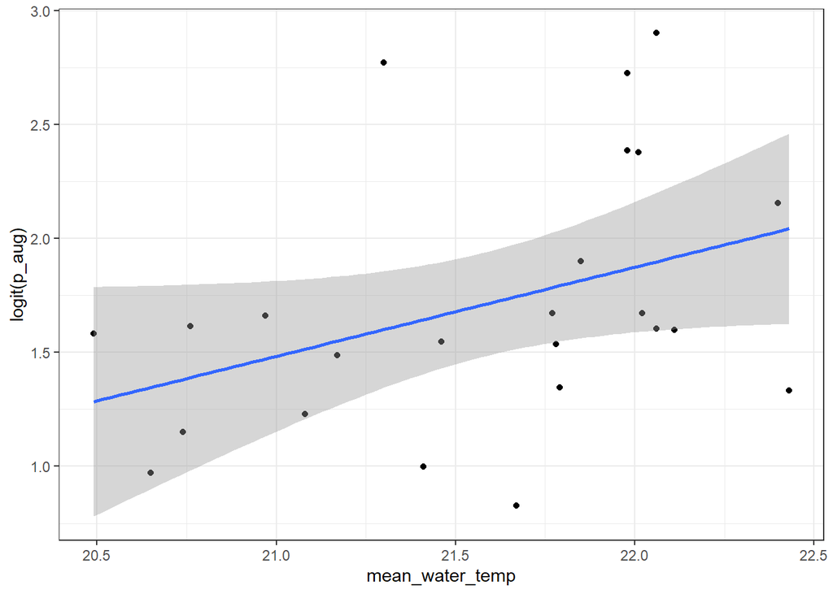

```r
ggplot(p_aug, aes(x=mean_water_temp,y=logit(`50%`)))+
  geom_point()+
  ylab("logit(p_aug)")+
  geom_smooth(method='lm', formula= y~x)+
  theme_bw()
```

```r
summary(lm(logit(`50%`)~mean_water_temp,data=p_aug))
```

```
##
## Call:
## lm(formula = logit(`50%`) ~ mean_water_temp, data = p_aug)
##
## Residuals:
##     Min      1Q  Median      3Q     Max
## -0.9172 -0.3001 -0.1134  0.2430  1.1718
##
## Coefficients:
##                 Estimate Std. Error t value Pr(>|t|)
## (Intercept)      -6.7346     4.2856  -1.571   0.1303
## mean_water_temp   0.3913     0.1985   1.971   0.0614 .
## ---
## Signif. codes:  0 '***' 0.001 '**' 0.01 '*' 0.05 '.' 0.1 ' ' 1
##
## Residual standard error: 0.5393 on 22 degrees of freedom
## Multiple R-squared:  0.1501, Adjusted R-squared:  0.1115
## F-statistic: 3.886 on 1 and 22 DF,  p-value: 0.06139
```

## Appendices

Below is the model used to estimate the jumper ratio, and the formatted data as supplied to the model

```r
noquote(read_lines("model/jumper.stan"))
```

```
##  [1] data{
##  [2]   int yrs; //number of years to make estimates
##  [3]   int years[yrs];//year indexes for years to make estimates
##  [4]   int a_yrs;//number of years of observed august abundance estimates
##  [5]   int a_years[a_yrs];  //year indexes for observed august abundance estimates
##  [6]   int s_yrs;//number of years of observed september abundance estimates
##  [7]   int s_years[s_yrs];//year indexes for observed september abundance estimates
##  [8]   int obs_yrs;//number of years with both observed august and september abundance estimates
##  [9]   int obs_years[obs_yrs];//indexes for years with both observed august and september abundance
## [10]   vector<lower=0>[a_yrs] N_aug_obs;//observed august abundance point estimate (median of pdf)
## [11]   vector<lower=0>[a_yrs] N_aug_sd_obs;//observed august abundance estimate lognormal sd
## [12]   vector<lower=0>[s_yrs] N_sept_obs;//observed september abundance estimate (median of pdf)
## [13]   vector<lower=0>[s_yrs] N_sept_sd_obs;//observed september abundance estimate lognormal sd
## [14]   int tr[obs_yrs];//observed trap count between august and september estimates
## [15] }
```

[output cut: 55 more lines]

```r
print(stan_dat)
```

```
## $year
##  [1] 2000 2001 2002 2003 2004 2005 2006 2007 2008 2009 2010 2011 2012 2013 2014
## [16] 2015 2016 2017 2018 2019 2020 2021 2022 2023
##
## $N_aug_obs
##  [1]  94 196 315 559 428 337 367 303 356 332 458 967 536 163 346 509 487 194 395
## [20] 257 437 157 766
##
## $august_cv
##  [1] 0.28 0.10 0.06 0.04 0.04 0.04 0.04 0.06 0.07 0.11 0.08 0.09 0.07 0.15 0.09
## [16] 0.06 0.07 0.11 0.09 0.08 0.13 0.32 0.09
##
## $august_l95
##  [1]  42 165 285 520 395 312 342 274 314 276 398 833 477 114 285 451 423 151 326
## [20] 214 330  59 622
##
## $august_u95
##  [1]  146  242  354  607  470  369  398  342  418  421  544 1190  615  211  407
## [16]  567  551  236  464  299  545  256  881
##
## $N_sept_obs
##  [1]  101  208  482  755  504  424  417  460  423  362  592 1238  651  551  204
## [16]  455  669  637  204  425  303  445  159  814
##
## $september_cv
##  [1] 0.23 0.08 0.05 0.04 0.04 0.09 0.04 0.05 0.05 0.06 0.05 0.09 0.05 0.06 0.14
## [16] 0.12 0.05 0.07 0.11 0.10 0.10 0.12 0.39 0.06
##
## $september_l95
##  [1]   73  181  437  701  464  361  389  421  384  324  537 1048  597  492  147
## [16]  354  606  556  161  342  242  343   53  723
##
## $september_u95
##  [1]  163  246  537  821  548  518  452  509  475  413  660 1499  719  628  260
## [16]  566  736  737  247  508  365  547  295  906
##
## $tr
##  [1] 11 10 42 33  6 35  4 40 14  6 42 32 22  4 13 25  7  4  5  7  3  0 12
##
## $N_aug_sd_obs
```

[output cut: 19 more lines]

```
##
## $a_yrs
## [1] 23
##
## $s_years
##  [1]  1  2  3  4  5  6  7  8  9 10 11 12 13 14 15 16 17 18 19 20 21 22 23 24
##
## $s_yrs
## [1] 24
##
## $obs_years
##  [1]  1  2  3  4  5  6  7  8  9 10 11 12 13 15 16 17 18 19 20 21 22 23 24
##
## $obs_yrs
## [1] 23
```